# Regional US Patterns

# Europe

## Italy, Spain and Portugal

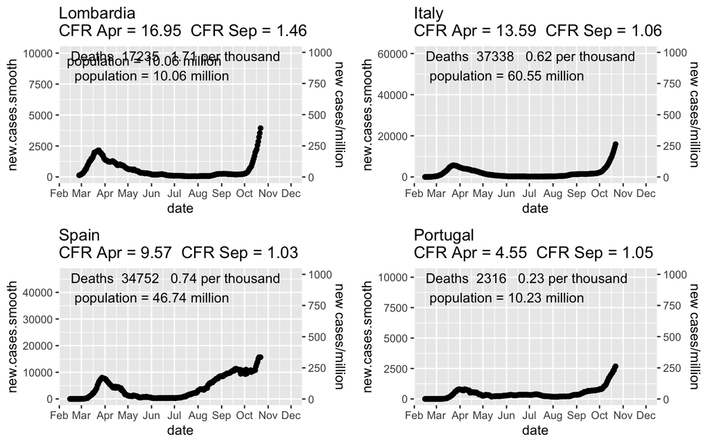

## France, Belgium, Netherlands, United Kingdom

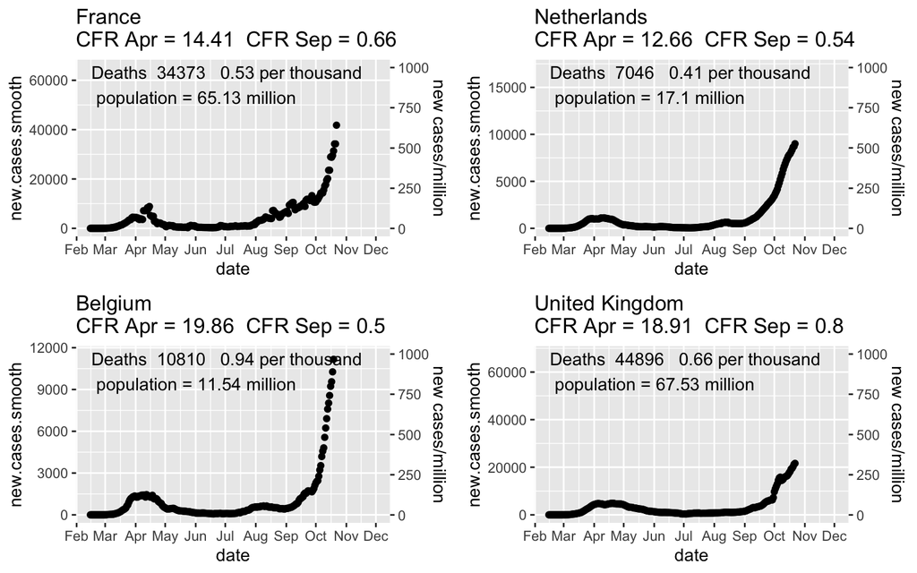

## Germany, Austria, Switzerland, Luxembourg

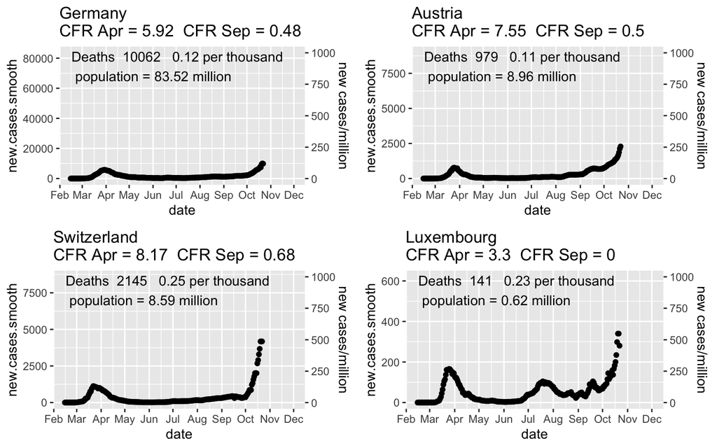

## Sweden, Norway, Finland, Denmark

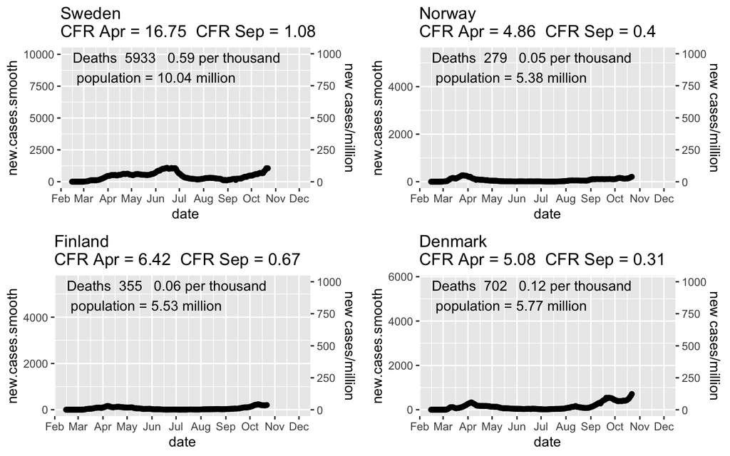

## Poland, Czechia, Slovakia, Hungary

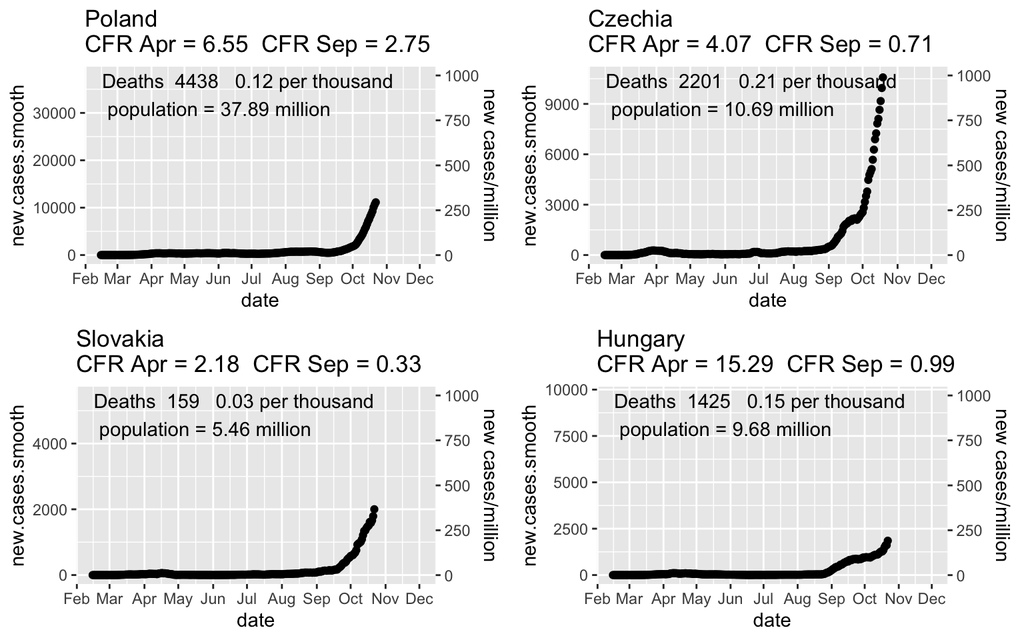

## Canada

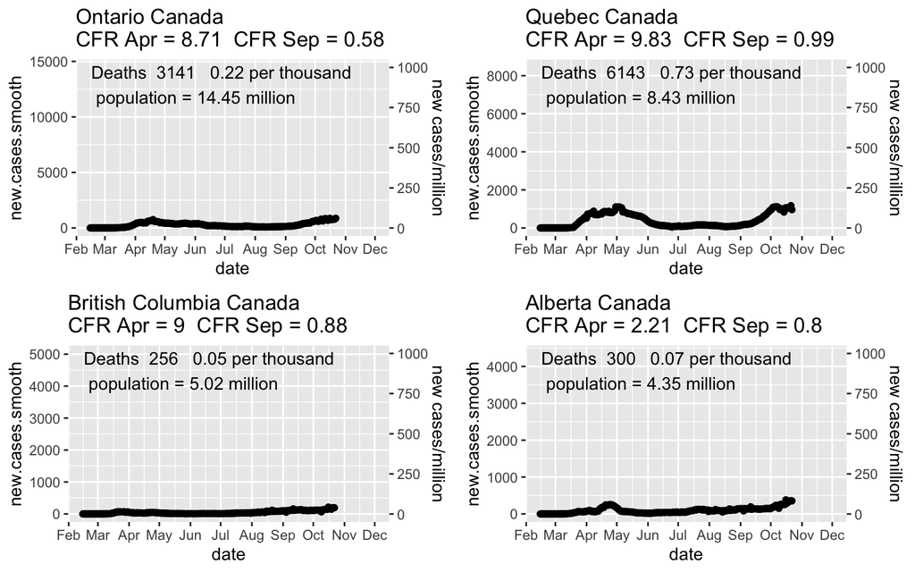

# United States

So many European countries are beginning or well into a fall surge in cases. How does the US look?

## Context

Before showing current cases per million. Here are the plots for some US counties where the local hospitals hit 100% capacity during a surge in cases. El Paso hospitals hit 100% for the ICU units on Oct 25th. So 750 cases per million appears to be a crisis number at the county level.

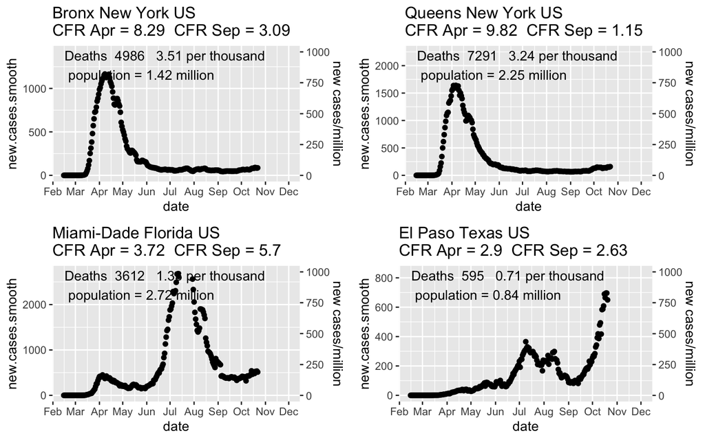

At the state level, these plots are averaging over counties with higher and lower cases per million but 500 appears to be a crisis number at the state level. There are 6 states that hit or got very close to a 3 day average of 500 new cases per million: NY, NJ, MS, LA, AZ and FL. This is a level where even state governments inclined not to close businesses will do so. At least that’s my read based on following the news and watching when GOP state governors shut down bars and gyms down.

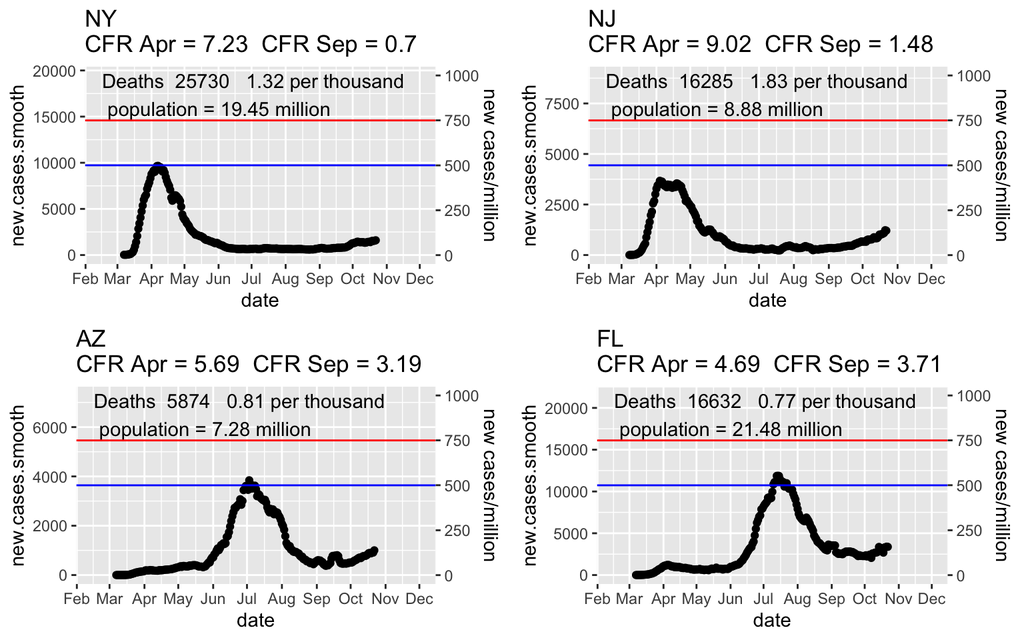

# Hotspots

The mountain west and Wisconsin are currently experiencing surges above 500 new cases per million and even above 750 in ND and SD.

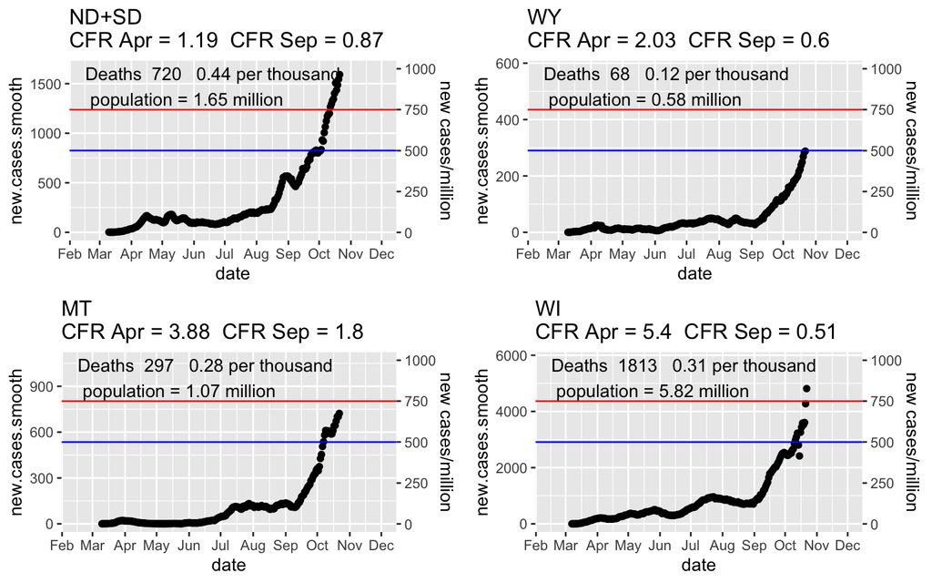

# Regional Trends

The regional trends are averaged over states with lower current cases and those with higher. They give a bit of a rosy picture with new cases per million generally below 250. However the surges that European countries are facing should caution against complacency and show how fast cases can rise.

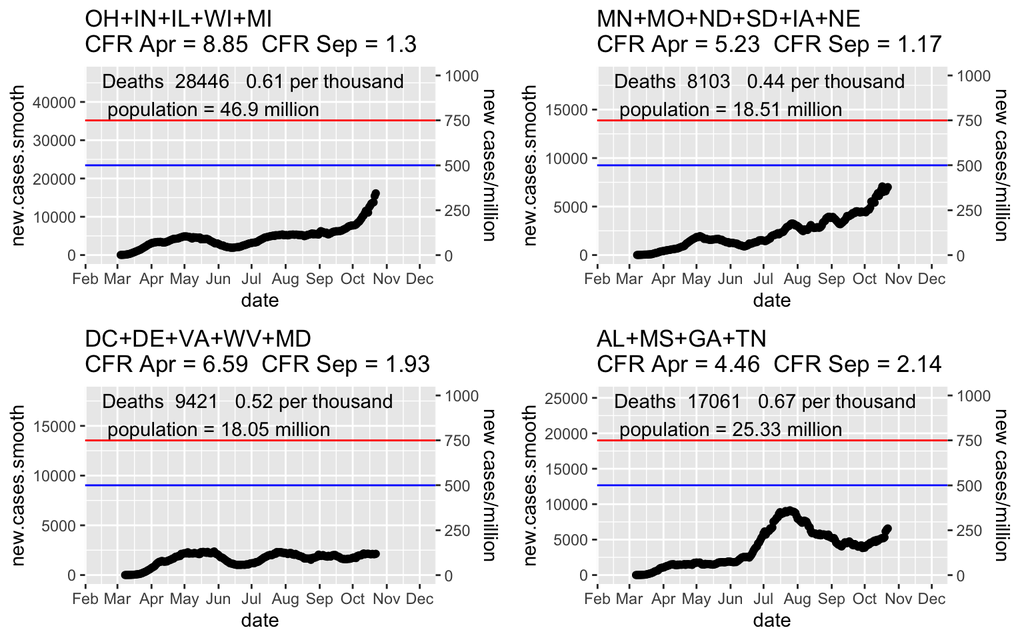

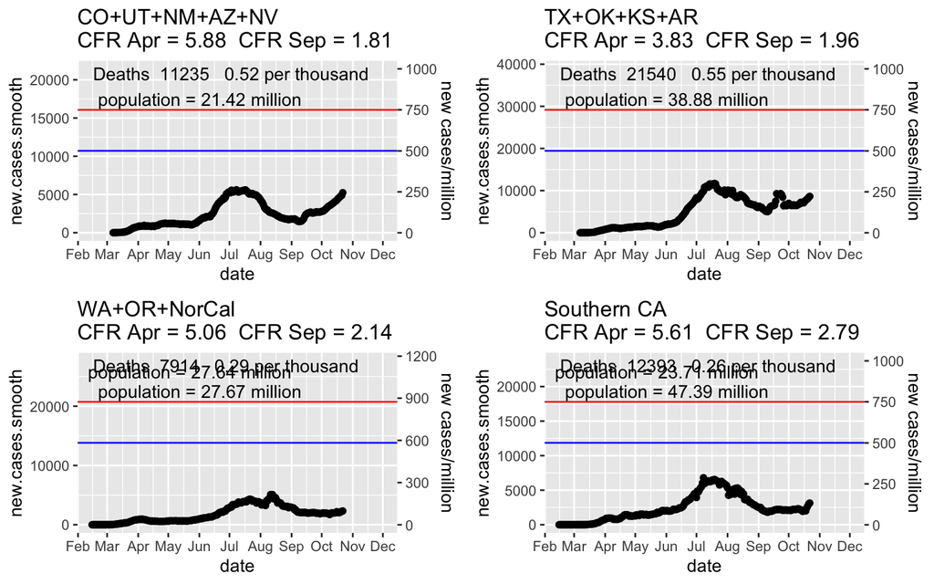

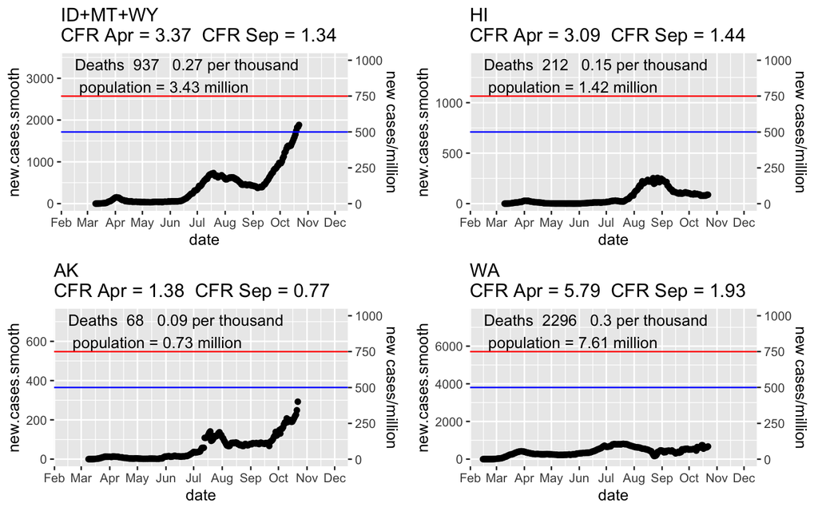